# Jednowymiarowe błądzenie losowe

Błądzenie losowe jako prosty model ruchu dyfuzyjnego.

Założymy, że wędrowniczek

\begin{itemize} \item w dyskretnych krokach czasowych $i=1,2,3,\ldots$ \item wykonuje niezależne kroki $d_1, d_2, d_3 ,\ldots$ o stałej długości \item kierunek kroku $d_i$ jest losowy \end{itemize}

W jednowymiarowym przypadku dla $|d_i|=1$ $$ d_i = \left{

\begin{array}{ll} 1 & \mbox{z }\;\; p=\frac{1}{2} \\ -1 & \mbox{z }\;\; p=\frac{1}{2} \end{array} \right. ,\;\;i=1,2,3,\ldots $$

Innymi słowy, wędrowiczek porusza się po węzłach jednowymiarowej sieci, $\ldots,-3,-2,-1,0,1,2,3,\ldots$. W każdym kroku czasowym przeskakuje on do jednego z dwóch sąsiednich węzłów z pradopodobieństwem $ p=\frac{1}{2}$.

### Trzy sposoby generowania spaceru losowego

```python
# Błądzenie na jednowymiarowej sieci
# Generowanie losowego kroku w pythonie - 3 SPOSOBY
import random

# pierwsza wersja generowania spaceru losowego
x0=0  #początek spaceru
x=x0
xw1=[x]
print('pierwszy spacer losowy')
#10 losowych kroków
for t in range(1,11):
    x=x+random.choice([-1, 1])  #losowy wybór -1 lub 1
    xw1.append(x)
print(xw1)


# druga wersja generowania spaceru losowego
x=x0
xw2=[x]
print('drugi spacer losowy')

for t in range(1,11):
    x=x+2*random.randint(0,1)-1 #2*random.randint(0,1)-1 = -1 lub 1
    xw2.append(x)
print(xw2)

# trzecia wersja generowania spaceru losowego
x=x0
xw3=[x]
print('trzeci spacer losowy')
for t in range(1,11):
    if random.random()<0.5: #z prawd. 1/2 x+1
        x=x+1
    else:                   #z prawd. 1/2 x-1
        x=x-1
    xw3.append(x)
print(xw3)
```

```
pierwszy spacer losowy
[0, -1, -2, -3, -2, -1, -2, -1, -2, -3, -2]
drugi spacer losowy
[0, -1, 0, 1, 0, 1, 0, -1, 0, -1, 0]
trzeci spacer losowy
[0, -1, -2, -3, -2, -3, -2, -3, -4, -5, -6]
```

### Animacja jednowymiarowego bładzenia

```python
#200 kroków spaceru
n=200
# początek spaceru
x=0
xa=[x]

for t in range(1,n):
    x=x+random.choice([-1, 1])  #losowy wybór -1 lub 1
    xa.append(x)
ya= []
ya.extend([0.5]*n)
mn=min(xa)
mx=max(xa)
dm=1
```

```python
%%capture
%matplotlib inline
import numpy as np
import matplotlib.pyplot as plt
import matplotlib.animation
plt.rcParams["animation.html"] = "jshtml"
plt.rcParams["figure.figsize"] = (12,0.5)
fig, ax = plt.subplots()
ax.set_xticks(np.arange(mn-dm,mx+dm,1))
ax.set_yticks(np.arange(0,1,1))
ax.set_yticklabels([])
ax.grid()
tyt=" Ruch wędrowniczka"
ax.set_title(tyt)
h = ax.axis([mn-dm,mx+dm,0,1])
lb, =ax.plot([],[],'or',markersize=10)

def animate(i):
    lb.set_data(xa[i], ya[i])
    return  lb,
animacja = matplotlib.animation.FuncAnimation(fig, animate, frames=len(xa))
```

```python
animacja
```

[figure not shown]

### Wykresy tras jednowymiarowego błądzenia losowego

```python
def wykres_spaceru(nk):
    a = np.zeros(nk)
    x=0
    a[0]=x
    for i in range(1,nk):
        x=x+random.choice([-1, 1])
        a[i]=x
    t = np.arange(nk)
    plt.rcParams["figure.figsize"] = (10,5)
    plt.plot(t,a)
    plt.ylabel('x')
    plt.xlabel('numer kroku')
    plt.show()
```

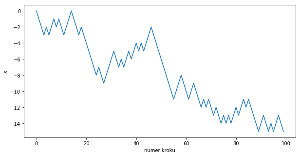

```python
wykres_spaceru(100)
```

### Położenie wędrowniczka po n krokach

Startując z położenia $x=0$, wędrowniczek po n krokach osiągnie położenie

\begin{equation}\label{eq:eq1} x_n=d_1+d_2+\cdots +d_n \end{equation}

Średnie położenie po n krokach

ponieważ $d_i$ są niezależne i $<d_i>=0$.

```python
# średnie położenie po nk krokach obliczone w ns spacerach
def av_x(nk,ns):
    avx=0.0
    for i in range(ns):
        x=0
        for _ in range(1,nk):
            x=x+random.choice([-1, 1])
        avx+=x
    return avx/ns
```

```python
# obliczymy <x> dla 100,10000 i 1000000 spacerów
ns=100
for _ in range(3):
    print("%7d  %12.8f"%(ns,av_x(100,ns)))
    ns*=100
```

```
    100   -0.94000000
  10000   -0.04920000
1000000   -0.00456600
```

### Średniokwadratowe przesunięcie - współczynnik dyfuzji

W jednowymiarowym błądzeniu losowym średniokwadratowe przesunięcie

\begin{equation}\label{eq:eq3} <(x_n-x_0)^2> \approx 2Dn \end{equation} gdzie D jest współczynnikiem dyfuzji

Dla $x_0=0$ i $|d_i|=1$

\begin{equation}\label{eq:eq4}

<x_n^2>=<(d_1+d_2+\cdots +d_n)^2>=<d_1^2>+<d_2^2>+\cdots +<d_n^2>=n<d_i^2>=n \end{equation}

W równaniu (\ref{eq:eq4}) wykorzystano niezależność kroków i fakt, że $<d_i^2>=1$

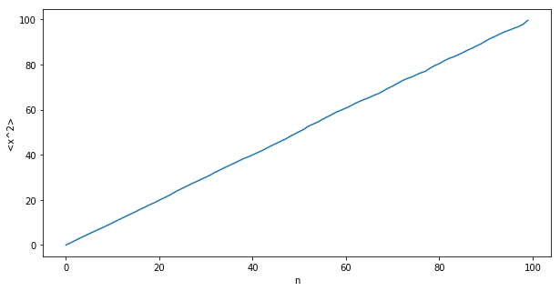

```python
# sredniokwadratowe przesunięcie
# nk - liczba kroków
# ns - liczba spacerów
def av_x2(nk,ns):
    av2=np.zeros(nk,dtype=float)
    for i in range(ns):
        x=0
        av2[0]+=x**2
        for k in range(1,nk):
            x=x+random.choice([-1, 1])
            av2[k]+=x**2
    return av2/ns
nk=100
r2=av_x2(nk,10000)

t=np.arange(nk)
plt.plot(t,r2)
plt.ylabel('<x^2>')
plt.xlabel('n')
plt.show()
```

```python
# współczynnik dyfuzji
# dopasujemy liniową zależnośc   r2 od n dla n>=50
D=np.polyfit(t[50:],r2[50:],1)[0]/2
print('D=',D)
```

```
D= 0.4953817527010801
```

### Rozkłady zakończenia błądzenia po n krokach

Zbadamy gdzie najczęciej kończą się spacery losowe po wykonaniu 100 kroków Zarejestrujemy wyniki dla 100 000 spacerów i wykreślimy histogram

```python
#histogram zakonczenia  ns spacerów  po nk krokach
def koniec_spaceru(nk,ns):
    ks=np.zeros(ns)
    for i in range(ns):
        x=0
        for k in range(1,nk):
            x=x+random.choice([-1, 1])
        ks[i]=x
    return ks


nk=101
ns=100000
xs = koniec_spaceru(nk,ns)
```

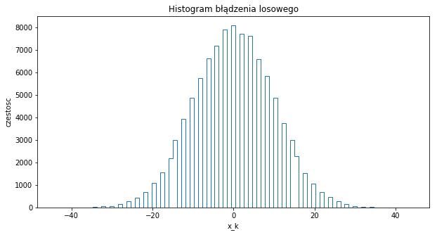

```python
# Histogram
nh, xh,pa = plt.hist(xs,85,histtype='step')
plt.xlabel('x_k')
plt.ylabel('czestosc')
plt.title('Histogram błądzenia losowego')
plt.show()
```

Rozkład zakończenia błądzenia w x=s po n krokach jest dla dużych n rozkładem Gaussa

\begin{equation}\label{eq:eqG} P(x=s)\backsim \exp(-\frac{s^2}{2n}) \end{equation}

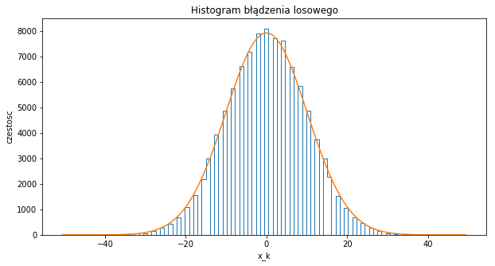

```python
# Histogram i rozkłąd Gaussa
nh, xh,pa = plt.hist(xs,85,histtype='step')
xg=np.arange(-nk/2,nk/2,1.0)
rg=2*ns*np.exp(-xg**2/(2*nk))/np.sqrt(2*np.pi*nk)
plt.plot(xg,rg)
plt.xlabel('x_k')
plt.ylabel('czestosc')
plt.title('Histogram błądzenia losowego')
plt.show()
```

### Błądzenie z węzłami odbijajacymi

Niech $-x_r$ i $x_r$ będą węzłami odbijającymi. W węzłąch odbijających obowiązują deterministyczne reguły. Gdy wędrowniczek wejdzie do węzła

\begin{itemize} \item $x_r$ to w następnym kroku ląduje w węźle $x_r-1$ \item $-x_r$ to w następnym kroku znajdzie się w węźle $-x_r+1$ \end{itemize}

Błądzenie losowe z węzłami odbijającycmi $x_r$ i $-x_r$ ograniczone jest do do przedziału $[-x_r,x_r]$

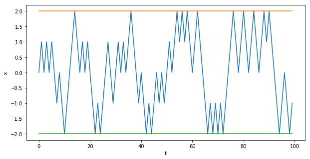

```python
def spacer_odbicie(nk,x0,xr):
    a = np.zeros(nk)
    x=x0
    a[0]=x
    for i in range(1,nk):
        if x==-xr:
            x=x+1
        elif x<xr:
            x=x+random.choice([-1, 1])
        else:
            x=x-1
        a[i]=x
    return a

xr=2
n1=100
t = np.arange(n1)
x1=spacer_odbicie(n1,0,xr)
plt.plot(t,x1)

plt.plot(t,np.ones(n1)*xr)
plt.plot(t,np.ones(n1)*(-xr))
plt.ylabel('x')
plt.xlabel('t')
plt.show()
```

### Rozkłady zakończenia spacerów z odbiciami

Zbadamy rozkady zakończenia spacerów z odbiciami po 100 krokach zmieniając rozstaw węzłów odbijających.

Wyniki dla $x_r$ od 4 do 24.

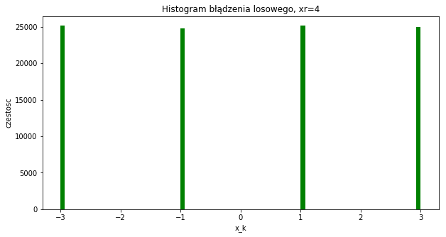

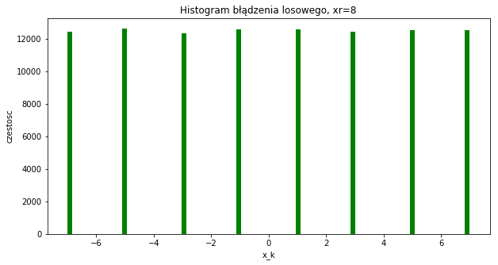

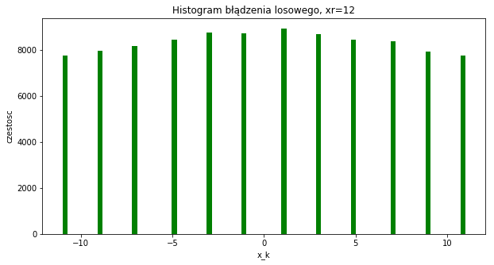

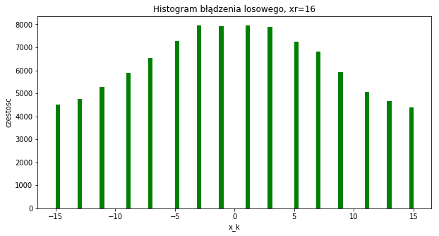

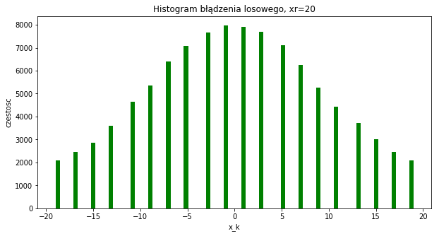

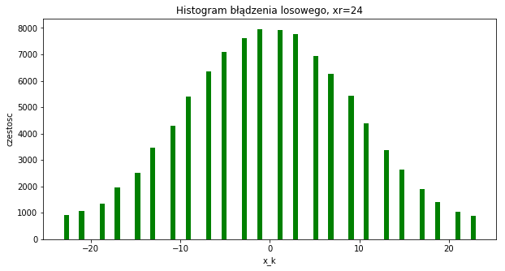

```python
#rozkłady zakończenia spacerów z odbiciem
def koniec_spaceru_odbicie(nk,x0,xr):
    x=x0
    for i in range(1,nk):
        if x==-xr:
            x=x+1
        elif x<xr:
             x=x+random.choice([-1, 1])
        else:
            x=x-1
    return x
n2=100
ns=100000
for xr in range(4,25,4):
    xs = np.zeros(ns)
    for i in range(ns):
        xs[i]=koniec_spaceru_odbicie(n2,0,xr)
# the histogram of the data
    n, bins, patches = plt.hist(xs, 81,  facecolor='g')

    plt.xlabel('x_k')
    plt.ylabel('czestosc')
    tytul = "Histogram błądzenia losowego, xr=" + str(xr)
    plt.title(tytul)
    plt.show()
```

### Błądzenie z węzłami pochłaniającymi

Teraz podobny przypadek ograniczonego błądzenia z węzłami pochłaniajacymi w $-x_a$ i $x_a$. Wędrowniczek kończy spacer, gdy dotrze do takiego węzła.

Liczba kroków w takim problemie nazywana jest czasem pierwszego przejścia

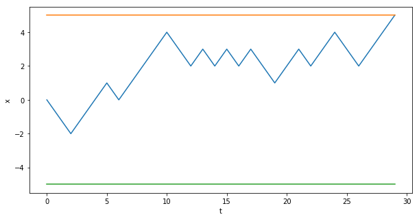

```python
#spacer z węzlami pochłaniająymi
def spacer_adsorpcja(x0,xa):
    x=x0
    a=([x])
    while (-xa<x and x<xa):
        x=x+random.choice([-1, 1])
        a.append(x)
    return a
xa=5
#t = np.arange(n1)
x1=spacer_adsorpcja(0,xa)
plt.plot(x1)
nx1=len(x1)
t = np.arange(nx1)
plt.plot(t,np.ones(nx1)*xa)
plt.plot(t,np.ones(nx1)*(-xa))
plt.ylabel('x')
plt.xlabel('t')
plt.show()
```

```python
#czas pierwszego przejscia - liczba kroków do węzła pochłaniającego
def czas_pas(x0,xa):
    x=x0
    i=0
    while (-xa<x and x<xa):
        x=x+random.choice([-1, 1])
        i=i+1
    return i
xa=5
x0=0
ns=20
t1p=[]
for _ in range (ns):
    t1p.append(czas_pas(x0,xa))
print(t1p)
```

```
[75, 33, 27, 5, 13, 23, 13, 11, 39, 7, 25, 7, 5, 11, 13, 43, 5, 7, 27, 27]
```

```python
#średni czas przejscia
xa=5
x0=0
tav=0
ns=100000
for _ in range (ns):
    tav=tav+czas_pas(x0,xa)
tav=tav/ns
print (tav)
```

```
24.96998
```

```
-4 9.1426 1.0158444444444443
-3 15.928 0.9955
-2 21.149 1.007095238095238
-1 24.0296 1.0012333333333332
0 24.8886 0.995544
1 24.0654 1.002725
2 21.2146 1.0102190476190476
3 15.9562 0.9972625
4 9.0046 1.0005111111111111
```

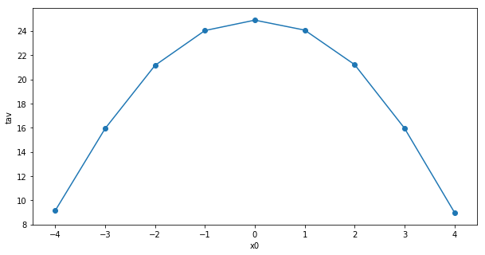

```python
#zależność średniego czasu przejscia od x0
ns=10000
xa=5
xp=([])
lt=([])
for x0 in range(-xa+1,xa,1):
    xp.append(x0)
    tav=0
    for _ in range (ns):
        tav=tav+czas_pas(x0,xa)
    tav=tav/ns
    lt.append(tav)
    print (x0,tav,tav/((x0+xa)*(xa-x0)))
plt.plot(xp,lt)
plt.scatter(xp,lt)
plt.ylabel('tav')
plt.xlabel('x0')
plt.show()
```

```
2 3.969 0.99225
3 8.8924 0.9880444444444445
4 15.7788 0.986175
5 25.0756 1.0030240000000001
6 36.0554 1.0015388888888888
7 49.1198 1.0024448979591836
8 64.7546 1.011790625
9 80.9044 0.9988197530864197
10 99.6814 0.996814
11 120.0078 0.9918
12 142.9846 0.9929486111111111
13 168.5212 0.9971668639053254
14 197.8582 1.009480612244898
15 224.8718 0.9994302222222222
```

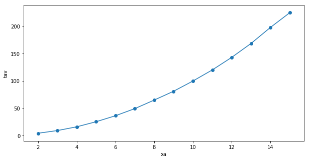

```python
#zależność średniego czasu przejscia od xa
ns=10000
x0=0
txa=([])
lt=([])
for xa in range(2,16,1):
    txa.append(xa)
    tav=0
    for _ in range (ns):
        tav=tav+czas_pas(x0,xa)
    tav=tav/ns
    lt.append(tav)
    print (xa,tav,tav/xa**2)
plt.plot(txa,lt)
plt.scatter(txa,lt)
plt.ylabel('tav')
plt.xlabel('xa')
plt.show()
```

```python
#prawdopodobienstwo pochłoniecia  w +xa
def r_ads(x0,xa):
    x=x0
    while (-xa<x and x<xa):
        x=x+2*random.randint(0,1)-1
        i=0
    if (x==xa):
            i=1
    return i

xa=5
ns=10000
for x0 in range (1-xa,xa,1):
    p_r=0
    for _ in range(ns):
        p_r=p_r+r_ads(x0,xa)
    p_r=p_r/ns
    print(x0,p_r)
```

```
-4 0.1017
-3 0.1987
-2 0.2989
-1 0.4073
0 0.4993
1 0.6048
2 0.6949
3 0.8037
4 0.8999
```

### Skorelowane błądzenie losowe (persited random walk)

W tym problemie prawdopodobieństwo przeskoku zależy od poprzedniego kroku

\begin{itemize} \item z pradopodobieństwem $p$ wędrowniczek kontynuuje spacer wzdłuż kierunku poprzedniego kroku \item z pradopodobieństwem $1-p$ wędrowniczek zmienia kierunek ruchu \end{itemize}

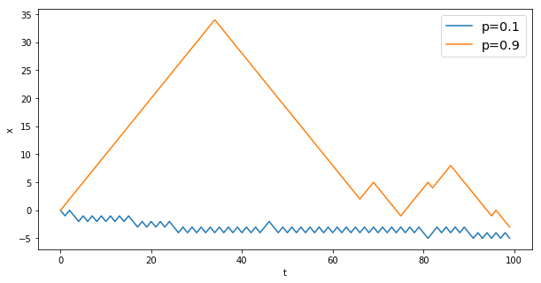

```python
# persisted random walk
# x0 - położenie początkowe
# nk - liczba kroków
# p - prawdopodobieństwo kontynuowania spaceru wzdłuż poprzedniego kierunku
def persisted_rw(nk,x0,p):
    a = np.zeros(nk)
    x=x0
    a[0]=x
    #początkowy kierunek
    krok=random.choice([-1, 1])

    for i in range(1,nk):
        # z prawdopodob. 1-p zmiana kierunku
        if random.random()>p:
            krok=-krok
        x=x+krok
        a[i]=x
    return a
n1=100
t = np.arange(n1)
p=0.1
x1=persisted_rw(n1,0,p)
plt.plot(t,x1,label='p=0.1')
p=0.9
x2=persisted_rw(n1,0,p)
plt.plot(t,x2,label='p=0.9')
#plt.plot(t,t)
#plt.plot(t,-t)
plt.ylabel('x')
plt.xlabel('t')
plt.legend( fontsize='x-large')
plt.show()
```

Zbadamy średniokwadratowe przesunięcie w bładzeniu skorelowanym

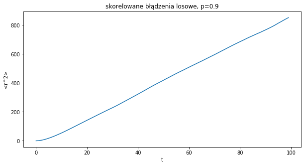

```python
#sredniokwadratowe przesunięcie w skorelowanym błądzeniu
n1=100 #liczba kroków
x0=10   #początek spaceru w x0
p=0.9 #prawdopob. kontynuacji
ns=10000  #liczba spacerów
r2 = np.zeros(n1) #sredniokwadratowe odchylenie
for i in range(ns):
    xt=persisted_rw(n1,x0,p)
    for l in range(n1):
        r2[l]=r2[l]+(xt[l]-x0)**2 #przyczynki do r2 w czasie t=l
for i in range(n1):
    r2[i]=r2[i]/ns  #średnia arytmentyczna

#wykres r2
t=np.arange(n1)
plt.plot(t,r2)
plt.ylabel('<r^2>')
plt.xlabel('t')
tytul = "skorelowane błądzenia losowe, p=" + str(p)
plt.title(tytul)
plt.show()
```

### Dokładne obliczenie prawdopodobieństwa w błądzeniu losowym

Niech P(x,n) oznacza prawdopodobieństwo,że po n krokach wędroniczek znajdzie się w punkcie x.

Obliczanie P(x,n) metodą macierzy przejścia

\begin{equation}\label{eq:mp1} P(x,n+1)=\frac{1}{2}P(x-1,n)+\frac{1}{2}P(x+1,n) \end{equation}

Założymy, że w chwili początkowej $P(x=0,n=0)=1$

```python
tmax=4
xc=4
nx=2*xc+1
ptx = np.zeros((nx,tmax))
ptx[xc,0]=1
#np.set_printoptions(precision=3)
np.set_printoptions(formatter={'float': '{: 0.3f}'.format})
print(ptx[:,0])
for n in range(1,tmax):
    for i in range(xc-n,xc+n+1,1):
        ptx[i,n]=0.5* ptx[i-1,n-1]+0.5* ptx[i+1,n-1]
    print(ptx[:,n])
```

```
[ 0.000  0.000  0.000  0.000  1.000  0.000  0.000  0.000  0.000]
[ 0.000  0.000  0.000  0.500  0.000  0.500  0.000  0.000  0.000]
[ 0.000  0.000  0.250  0.000  0.500  0.000  0.250  0.000  0.000]
[ 0.000  0.125  0.000  0.375  0.000  0.375  0.000  0.125  0.000]
```

Mając obliczone P(i,n) możemy obliczyć średniokwadratowe przesunięcie

\begin{equation}\label{eq:}

<x^2(n)>=\sum_i{P(i,n)(i-x_c)^2} \end{equation}

dla warunku początkowego $P(x_c,0)=1$

```
[ 0.000  1.000  2.000  3.000  4.000  5.000  6.000  7.000  8.000  9.000
  10.000  11.000  12.000  13.000  14.000  15.000  16.000  17.000  18.000
  19.000  20.000  21.000  22.000  23.000  24.000  25.000  26.000  27.000
  28.000  29.000  30.000  31.000  32.000  33.000  34.000  35.000  36.000
  37.000  38.000  39.000  40.000  41.000  42.000  43.000  44.000  45.000
  46.000  47.000  48.000  49.000  50.000  51.000  52.000  53.000  54.000
  55.000  56.000  57.000  58.000  59.000  60.000  61.000  62.000  63.000
  64.000  65.000  66.000  67.000  68.000  69.000  70.000  71.000  72.000
  73.000  74.000  75.000  76.000  77.000  78.000  79.000  80.000  81.000
  82.000  83.000  84.000  85.000  86.000  87.000  88.000  89.000  90.000
  91.000  92.000  93.000  94.000  95.000  96.000  97.000  98.000  99.000
  100.000]
```

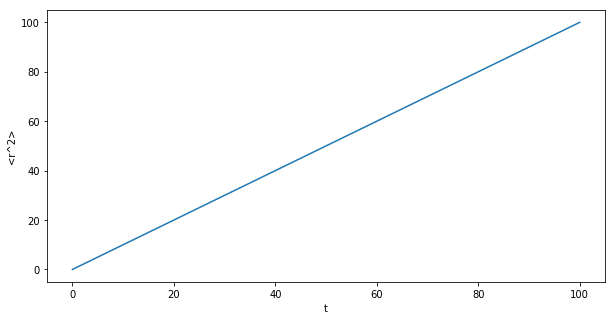

```python
#obliczanie P(x,n) i r2(n)
tmax=101
xc=102
nx=2*xc+1
ptx = np.zeros((nx,tmax))
ptx[xc,0]=1
for n in range(1,tmax):
    for i in range(xc-n,xc+n+1,1):
        ptx[i,n]=0.5* ptx[i-1,n-1]+0.5* ptx[i+1,n-1]
r2=np.zeros(tmax)
for n in range(tmax):
    for i in range(nx):
        r2[n]=r2[n]+ptx[i,n]*(i-xc)**2
print(r2)
lt=np.arange(tmax)
plt.plot(lt,r2)
plt.ylabel('<r^2>')
plt.xlabel('t')
plt.show()
```